# house_pricing

## Housing market in the Laurentides region

### Table of content

1. Introduction
2. Data preparation
3. Statistical evaluation of current listings (January 2021)
4. Modeling of a new listing price predicter
5. Price evaluation of current listing

# 1. Introduction

### **Context:**

We are in January 2021 and the Covid-19 pandemic his driving the housing market in the Montreal region to new highs. My partner and I have the desire to get ''on the train'' while we can and before the prices are to steep. This study is meant for us to understand the market and help us make a good decision regarding the house we will buy. It also lays the foundations for further possible business developments.

The study will be biased towards **our dream house characteristics**:

Minimum **three bedrooms**

Minimum **two bathroooms**

A **decently sized house - between 1200 and 1500 sq.ft**

A **decently sized land - between 10000 and 20000 sq.ft** away from road noise

A **garage** so I can fullfill my handyman side

### **Business questions this study intends to answer:**

Study the Laurentides region market characteristics: i.e. statistical analysis of current listings

Be able to provide a market price for a potential new listing using its characteristics

Be able to tell if any of the current listings are considered under-priced, fairly-priced or over-priced

### **Data characteristics:**

123 house listings were manually (because a lot of variables are subjective and needed analysis) gathered between the last week of December 2020 and the first week of January 2021. They represent all the listings for houses with **prices between 200000 and 500000$** and located within the **following municipalities**: Piedmont, Sainte-Adèle, Saint-Sauveur, Sainte-Agathe-des-Monts, Val-David, Saint-Adolphe-d'Howard, Morin-Heights and Val-Morin.

# 2. Data Preparation

### 2.1 Importation of the libraries to be used during this study

|  | Bedrooms | Bathrooms | Village | Proxi-ski | Road | Water-access | Garage | Year | Price | Municipality | Renovations | Warranty | Land | Rooms | Living_area | Address | Link |
| --- | --- | --- | --- | --- | --- | --- | --- | --- | --- | --- | --- | --- | --- | --- | --- | --- | --- |
| 0 | 2 | 1 | oui | non | non | non | non | 1999 | 215000 | Sainte-Agathe-des-Monts | non | oui | 6600 | 6 | 800 | 20, Rue Saint-Jacques, Sainte-Agathe-des-Monts | https://www.centris.ca/fr/maison~a-vendre~sain... |
| 1 | 3 | 3 | oui | non | oui | non | non | 2019 | 320000 | Sainte-Adèle | oui | oui | 2024 | 10 | 2088 | 903, Rue Sigouin, Sainte-Adèle, | https://www.centris.ca/fr/maison~a-vendre~sain... |

### 2.2 Data manipulations prior to analysis

|  | Bedrooms | Bathrooms | Village | Proxi-ski | Road | Water-access | Garage | Year | Price | Municipality | Renovations | Warranty | Land | Rooms | Living_area | Address | Link | Price_per_house_size | Price_per_land_size |
| --- | --- | --- | --- | --- | --- | --- | --- | --- | --- | --- | --- | --- | --- | --- | --- | --- | --- | --- | --- |
| 0 | 2 | 1 | 1 | 0 | 0 | 0 | 0 | 1999 | 215000 | Sainte-Agathe-des-Monts | 0.0 | 1 | 6600 | 6 | 800 | 20, Rue Saint-Jacques, Sainte-Agathe-des-Monts | https://www.centris.ca/fr/maison~a-vendre~sain... | 268.750000 | 32.575758 |
| 1 | 3 | 3 | 1 | 0 | 1 | 0 | 0 | 2019 | 320000 | Sainte-Adèle | 1.0 | 1 | 2024 | 10 | 2088 | 903, Rue Sigouin, Sainte-Adèle, | https://www.centris.ca/fr/maison~a-vendre~sain... | 153.256705 | 158.102767 |

### 2.3 Variables Description

#### Quantitave data:

**Bedrooms:** The number of bedrooms in the house

**Bathrooms:** The number of bathrooms in the house

**Price:** The house price

**Land:** The land dimensions in sq.ft

**Rooms:** The number of rooms in the house

**Living_area:** The house living_area dimensions in sq.ft

**Prix_per_house_size:** The house price in terms of dollars / sq.ft

**Price_per_land_size:** The land price in terms of dollars / sq.ft

#### Categorical data:

**Village:** Is the house located in the hearth of the village or not?

**Road:** Is the house located close to a busy road or not?

**Water-access:** Is the house located near a river or a lake?

**Garage:** Does the house have a garage or not?

**Year:** When was the house built?

**Municipality:** In which municipality is the house located?

**Renovations:** In the house renovated?

**Warranty:** Is the house covered under a warranty?

# 3. Statistical evaluation of current listings (January 2021)

## 3.1 Statistical distribution of quantitative variables

```
It is interesting to see that the average current house on sale in the Laurentides has:
3.0 bedrooms
2.0 bathrooms
10.0 rooms
a living area of 1705.0 square feet
a land of 30190.0 square feet
a goes for an average price of 354974.0

All of this pretty much in line with our expectations described in the intro! yeah!
```

## 3.2 Univariate Analysis

In this section we will study the distribution of categorical and quantitative variables:

**Categorical variables** are qualitative and can either be ordinal (rank) or nominal (no rank)

**Quantitative variables** can either be continuous (price) or discrete (number or rooms)

### 3.2.1 Categorical Data

```
let's look at the distribution (in %) of the main categorical variables across all listings
0 means 'no', 1 means 'yes'
```

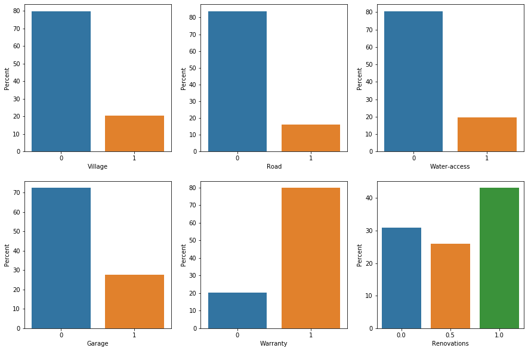

### 3.2.1.1 Discussion on categorical data

As it can be seen above, the vast majority of house currently on sale are:

not located in the hearth of a village (more or less 80%)

not close to a major road (more or less 80%)

do not have access to a river or a lake (more or less 80%)

do not have a garage (more or less 70%)

come with a warranty (more or less 80%)

partly or fully renovated (more or less 70%)

At the light of this, it is understood that finding a house with a garage and with water access might be more difficult and this is to be kept in mind.

### 3.2.2 Quantitive Data

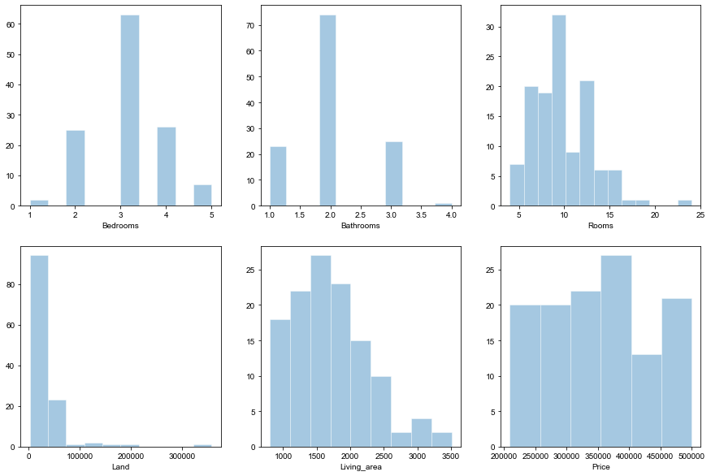

### 3.2.2.1 Discussion on quantitative data

As it can be seen above and as explained previously in the report, the vast majority of house currently on sale have three bedrooms, two bathrooms and ten rooms with a living area around 1500 sq.ft.

It is also interesting to see that the price distribution seem to follow something like an uniform distribution with small peeks between 300000 and 400000$.

## 3.3 Multivariable Analysis

In this section we will study the distribution of categorical and quantitative variables against other variables to see if we can establish which ones have influence on others.

We are obviously mostly interested by a given variable influence on price.

### 3.3.1 Categorical variables

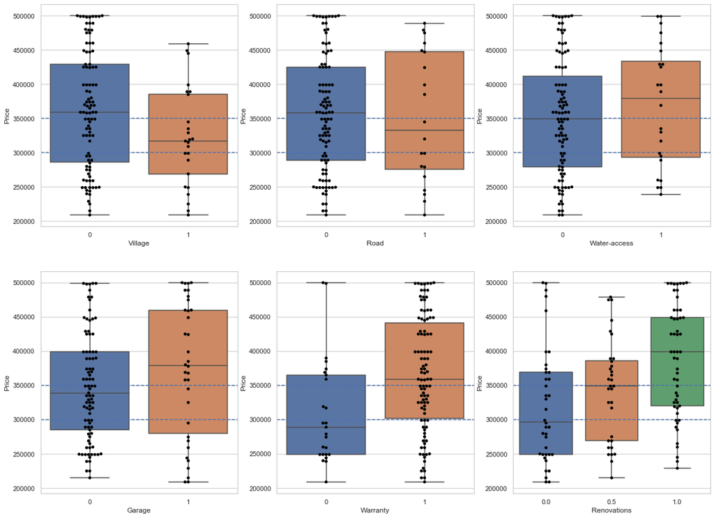

### 3.3.1.1 Discussion on categorical variable

These boxplots show the influence of the categorical variables on house price. We can see that a house far from a road, with water access, a garage, a warranty and renovated will command a higher sell price.

Contrary to what we would have expected, a house located in a village sells for less than a house located in the woods. This is probably explained by the lot size.

A semi or full renovated houses will for its part sell 50000 and 100000 dollars more than one that is not renovated.

### 3.3.2 Quantitative variables

```
No handles with labels found to put in legend.
No handles with labels found to put in legend.
No handles with labels found to put in legend.
```

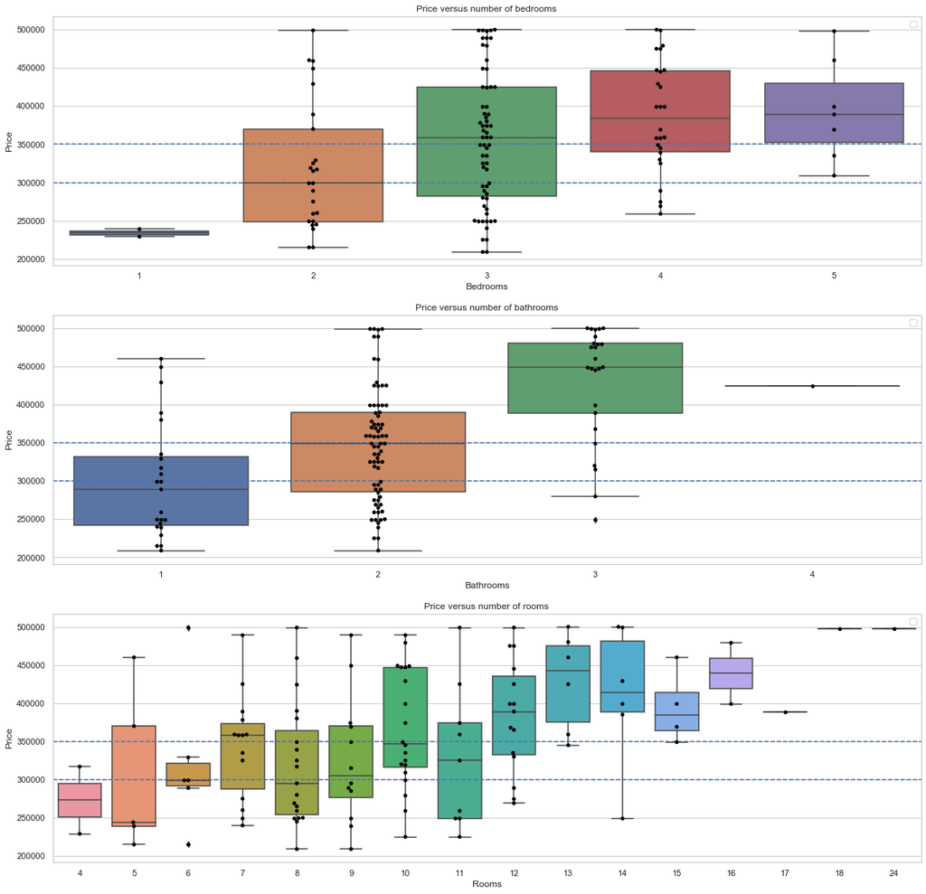

```
No handles with labels found to put in legend.
No handles with labels found to put in legend.
```

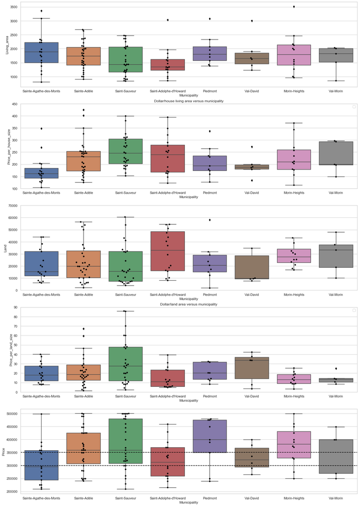

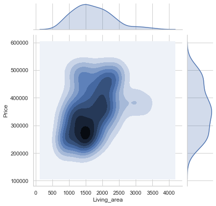

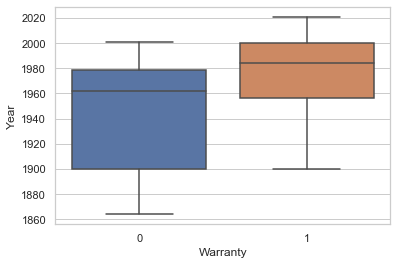

### 3.3.2.1 Discussion on multivariable analysis

The first set of boxplots show the influence of the quantitative variables on house price. As excepted, the more bedrooms / bathrooms and rooms a house has, the highest is price is. The trends seem linear but plateaus in the higher independent variables suggest the trends might more towards logarithmic relationships.

The second set of boxplots represents the distribution of house size (in sq.ft), land size (in sq.ft) dollar/house area, dollar/land area and price versus municipality. The analysis of these graphs show that the house size is typically larger in Sainte-Agathe-des-Monts with a unit cost per area considerably cheaper than in the other towns. The median of the listings in this municipality is the lowest amongst all of them. The median listing in Saint-Adolphe-d’Howard provides a smaller house but a bigger land when compared to the other towns.

Finnaly, we can observe that listings offering a warranty are typically newer constructions. The median listing offering a warranty is built in 1980 compared to 1960 for a listing not offering a warranty.

# 4. Modeling of a new listing price predicter

**Context:**

The idea behind this predicter is for us to determine the price of a house based on the attributes we want it to have. We will build a predicter and use the house values below but the user can input the values of its choice:

Minimum **three bedrooms**

Minimum **two bathroooms**

A **decently sized house - between 1200 and 1500 sq.ft**

A **decently sized land - between 10000 and 20000 sq.ft** away from road noise

A **garage** so I can fullfill my handyman side

We are not set yet on the municapility we want to live in, the predictor will help find which one would have a house that fits our needs.

**Methodology:**

Given the previous analysis, we chose the variables that had a clear influence on price to build the predictive model:

Bedrooms

Bathrooms

Rooms

Living area (sq.ft)

Land area (sq.ft)

Garage

Water access

Renovations

Warranty

Renovations

Municipality

The model will either be based on a multivariate linear regression, multivariate polynomial regression or a KNN (K-nearest neighbors) algorithm.

After that, we will train the three different models described before and see which one yields the best results (i.e. the best variance score). We will pick the best of them to estimate the price of our dream house! :)

## 4.1 Determination of best random split

```
we convert the categorical variables to numerical variables: 0s or 1s
```

|  | Bedrooms | Bathrooms | Village | Proxi-ski | Road | Water-access | Garage | Year | Price | Renovations | ... | Link_https://www.centris.ca/fr/maison~a-vendre~val-david/10008889?view=Summary&uc=43 | Link_https://www.centris.ca/fr/maison~a-vendre~val-david/11607185?view=Summary&uc=43 | Link_https://www.centris.ca/fr/maison~a-vendre~val-david/13023360?view=Summary&uc=18 | Link_https://www.centris.ca/fr/maison~a-vendre~val-david/16110695?view=Summary&uc=18 | Link_https://www.centris.ca/fr/maison~a-vendre~val-david/25303149?view=Summary&uc=44 | Link_https://www.centris.ca/fr/maison~a-vendre~val-morin/11016731?view=Summary&uc=44 | Link_https://www.centris.ca/fr/maison~a-vendre~val-morin/15012319?view=Summary&uc=18 | Link_https://www.centris.ca/fr/maison~a-vendre~val-morin/19432394?view=Summary&uc=18 | Link_https://www.centris.ca/fr/maison~a-vendre~val-morin/28353837?view=Summary&uc=43 | Link_https://www.centris.ca/fr/maison~a-vendre~val-morin/9056550?view=Summary&uc=44 |
| --- | --- | --- | --- | --- | --- | --- | --- | --- | --- | --- | --- | --- | --- | --- | --- | --- | --- | --- | --- | --- | --- |
| 0 | 2 | 1 | 1 | 0 | 0 | 0 | 0 | 1999 | 215000 | 0.0 | ... | 0 | 0 | 0 | 0 | 0 | 0 | 0 | 0 | 0 | 0 |
| 1 | 3 | 3 | 1 | 0 | 1 | 0 | 0 | 2019 | 320000 | 1.0 | ... | 0 | 0 | 0 | 0 | 0 | 0 | 0 | 0 | 0 | 0 |
| 2 | 3 | 2 | 1 | 0 | 0 | 0 | 0 | 1946 | 334900 | 1.0 | ... | 0 | 0 | 0 | 0 | 0 | 0 | 0 | 0 | 0 | 0 |
| 3 | 2 | 1 | 0 | 0 | 0 | 0 | 1 | 1900 | 215000 | 0.5 | ... | 0 | 0 | 0 | 0 | 0 | 0 | 0 | 0 | 0 | 0 |
| 4 | 1 | 1 | 0 | 0 | 1 | 0 | 1 | 1970 | 229000 | 1.0 | ... | 0 | 0 | 0 | 0 | 0 | 0 | 0 | 0 | 0 | 0 |

5 rows × 268 columns

**Methodology:**

1. We loop items 2 to 6:

2. we split the data into Train and Test.

3. We scale the training set to get better results.

4. We fit a multivariate linear regression model

5. We estimate the sell price of the training set

6. We check the variance

7. We select the seed that provides the best variance score")

```
we see that seed # 2090 yields an explained score of 0.8375967184326683
```

We then split our dataset (train & test) using the seed above 84% of all listing being in the train dataset

## 4.2 Determination of which model provides the best variance

### 4.2.1 Multivariate Linear Regression

We fit our multivariate linear regression model and find the corresponding variance score

```
Residual sum of squares: 1130236921.32
Variance score: 0.84
```

### 4.2.2 Multivariate Polynomial Regression

```
Residual sum of squares: 1316166025.30
Variance score: 0.81
```

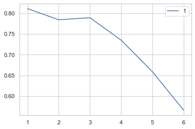

### 4.2.3 K-Nearest Neighbors

```
Residual sum of squares: 2923277142.86
Variance score: 0.58
```

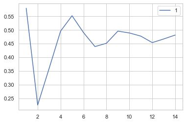

### 4.2.4 Discussion

We can see that the multivariate linear regression model yielded better variance results than the other two model (linear: 84, polynomial order 1: 0.81 and knn: 0.58). Obviously, the seed was selected to optimize the variance of the linear model but the fact that most inter-variable relationships explored above seemed linear also helps to explain the results.

Looking at the chart and table below, we see that the error distribution between predicted and actual values is skewed to the left with min. and max. differences being around 50000 dollars. The standard error being around 30000 dollar satisfies us.

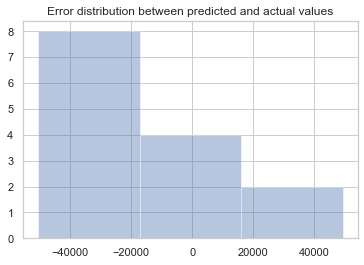

|  | 0 |
| --- | --- |
| count | 14.000000 |
| mean | -17007.138026 |
| std | 30094.618079 |
| min | -50465.545521 |
| 25% | -44714.374659 |
| 50% | -21527.427042 |
| 75% | 3523.207092 |
| max | 49184.673884 |

## 4.3 Determination of our dream house price

Let's now find the price of our dream house in the different towns

For the estimate, we will take the following characteristics for our dream home:

Three bedrooms

Two bathroooms

Nine rooms

A house of 1300 sq.ft

A land of 15000 sw.ft away from road noise

No water access

Partly renovated

With a warranty

A garage

```
user prompts here the values of his choice
How many bedrooms?: 3
How many bathrooms?: 2
How many rooms?: 9
House area in sq.ft?: 1300
Land area in sq.ft?: 15000
Water access? yes:1, no:0: 0
Renovated? yes:1, semi:0.5, no:00.5
Warranty? yes:1, no:0: 1
Garage? yes:1, no:0: 1
```

```
We prepare the matrix to feed the predictive model
```

|  | Bedrooms | Bathrooms | Living_area | Garage | Water-access | Renovations | Warranty | Rooms | Municipality | Land | Price |
| --- | --- | --- | --- | --- | --- | --- | --- | --- | --- | --- | --- |
| 5 | 3 | 2 | 1300 | 1 | 0 | 0.5 | 1 | 9 | Sainte-Agathe-des-Monts | 15000 | 302077.0 |
| 6 | 3 | 2 | 1300 | 1 | 0 | 0.5 | 1 | 9 | Val-David | 15000 | 308563.0 |
| 2 | 3 | 2 | 1300 | 1 | 0 | 0.5 | 1 | 9 | Saint-Adolphe-d'Howard | 15000 | 310287.0 |
| 7 | 3 | 2 | 1300 | 1 | 0 | 0.5 | 1 | 9 | Val-Morin | 15000 | 321678.0 |
| 0 | 3 | 2 | 1300 | 1 | 0 | 0.5 | 1 | 9 | Morin-Heights | 15000 | 346961.0 |
| 4 | 3 | 2 | 1300 | 1 | 0 | 0.5 | 1 | 9 | Sainte-Adèle | 15000 | 348864.0 |
| 1 | 3 | 2 | 1300 | 1 | 0 | 0.5 | 1 | 9 | Piedmont | 15000 | 354285.0 |
| 3 | 3 | 2 | 1300 | 1 | 0 | 0.5 | 1 | 9 | Saint-Sauveur | 15000 | 358038.0 |

We scale the matrix and feed the predictive model with it. We then plot the prices by municipality

```
(280000, 400000)
```

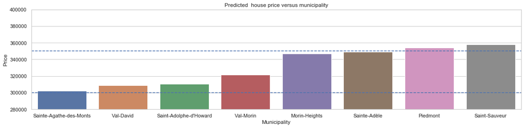

## 4.4 Discussion on predicted house prices

Obviously this represents just an estimate of a sell price, we have to remember that the standard deviation of the difference between the predicted values and the actual values is around 30000 dollars. This is to say that we could be lucky and find a house with the characteristics we want in Morin-Heights with a price within the standard error and still respect our price range / capabilities.

This brings the next section where will determine which listings are under-priced and righlty-priced.

# 5. Price evaluation of current listing

As described in the previous section, we now will evaluate each listing on the market and determine if they are properly priced.

This will enable us to see which listings are considered good opportunities and which ones are considered rightly priced.

A righlty priced listing will be a case where the estimated price will be plus or minus 10000 than the actual sell price

To keep things simple, we will search for listings using only three parameters: three bedrooms, two bathrooms, a warranty and a sell price above 275000 dollars and below 360000 dollars.

```
Under-priced listings
```

|  | Bedrooms | Bathrooms | Village | Proxi-ski | Road | Water-access | Garage | Year | Price | Municipality | Renovations | Warranty | Land | Rooms | Living_area | Address | Link | Estimated_Price | Delta_Price |
| --- | --- | --- | --- | --- | --- | --- | --- | --- | --- | --- | --- | --- | --- | --- | --- | --- | --- | --- | --- |
| 2 | 3 | 2 | oui | non | non | non | non | 1946 | 334900 | Saint-Sauveur | oui | oui | 3900 | 7 | 1221 | 24, Avenue Chartier, Saint-Sauveur | https://www.centris.ca/fr/maison~a-vendre~sain... | 352892.158637 | 17992.158637 |
| 6 | 3 | 2 | non | non | non | non | non | 1973 | 285000 | Saint-Sauveur | oui | oui | 5988 | 9 | 925 | 87, Avenue Léonie, Saint-Sauveur | https://www.centris.ca/fr/maison~a-vendre~sain... | 354889.213991 | 69889.213991 |
| 41 | 3 | 2 | non | non | non | non | non | 1994 | 349000 | Piedmont | oui | oui | 17220 | 10 | 1950 | 192, Chemin du Puits, Piedmont | https://www.centris.ca/fr/maison~a-vendre~pied... | 383527.469666 | 34527.469666 |
| 47 | 3 | 2 | non | non | non | non | non | 1988 | 325000 | Sainte-Adèle | semi | oui | 19632 | 7 | 1831 | 890, Rue de la Terrasse, Sainte-Adèle, | https://www.centris.ca/fr/maison~a-vendre~sain... | 340188.753589 | 15188.753589 |
| 73 | 3 | 2 | non | non | non | non | non | 2007 | 325000 | Sainte-Agathe-des-Monts | oui | oui | 33640 | 11 | 1880 | 581, Rue du Plateau, Sainte-Agathe-des-Monts | https://www.centris.ca/fr/maison~a-vendre~sain... | 342166.092727 | 17166.092727 |
| 80 | 3 | 2 | non | non | non | non | non | 1900 | 359000 | Saint-Sauveur | non | oui | 41027 | 13 | 2360 | 43, Chemin du Geai-Bleu, Saint-Sauveur | https://www.centris.ca/fr/maison~a-vendre~sain... | 369405.288167 | 10405.288167 |

```
Rightly-priced listings
```

|  | Bedrooms | Bathrooms | Village | Proxi-ski | Road | Water-access | Garage | Year | Price | Municipality | Renovations | Warranty | Land | Rooms | Living_area | Address | Link | Estimated_Price | Delta_Price |
| --- | --- | --- | --- | --- | --- | --- | --- | --- | --- | --- | --- | --- | --- | --- | --- | --- | --- | --- | --- |
| 13 | 3 | 2 | non | non | non | non | non | 1973 | 345000 | Saint-Sauveur | semi | oui | 7200 | 10 | 1150 | 839, Chemin des Pentes, Saint-Sauveur | https://www.centris.ca/fr/maison~a-vendre~sain... | 338885.292849 | -6114.707151 |
| 24 | 3 | 2 | non | non | non | non | non | 1975 | 359000 | Sainte-Adèle | oui | oui | 10162 | 7 | 1924 | 300, Rue des Bosquets, Sainte-Adèle, | https://www.centris.ca/fr/maison~a-vendre~sain... | 362614.179400 | 3614.179400 |

Let's obtain the latitudes and longitudes for each of team

[output not shown]

|  | Bedrooms | Bathrooms | Village | Proxi-ski | Road | Water-access | Garage | Year | Price | Municipality | ... | Warranty | Land | Rooms | Living_area | Address | Link | Estimated_Price | Delta_Price | Latitude | Longitude |
| --- | --- | --- | --- | --- | --- | --- | --- | --- | --- | --- | --- | --- | --- | --- | --- | --- | --- | --- | --- | --- | --- |
| 2 | 3 | 2 | oui | non | non | non | non | 1946 | 334900 | Saint-Sauveur | ... | oui | 3900 | 7 | 1221 | 24, Avenue Chartier, Saint-Sauveur | https://www.centris.ca/fr/maison~a-vendre~sain... | 352892.158637 | 17992.158637 | 45.895123 | -74.160931 |
| 6 | 3 | 2 | non | non | non | non | non | 1973 | 285000 | Saint-Sauveur | ... | oui | 5988 | 9 | 925 | 87, Avenue Léonie, Saint-Sauveur | https://www.centris.ca/fr/maison~a-vendre~sain... | 354889.213991 | 69889.213991 | 45.883685 | -74.166841 |
| 41 | 3 | 2 | non | non | non | non | non | 1994 | 349000 | Piedmont | ... | oui | 17220 | 10 | 1950 | 192, Chemin du Puits, Piedmont | https://www.centris.ca/fr/maison~a-vendre~pied... | 383527.469666 | 34527.469666 | 45.909446 | -74.137353 |
| 47 | 3 | 2 | non | non | non | non | non | 1988 | 325000 | Sainte-Adèle | ... | oui | 19632 | 7 | 1831 | 890, Rue de la Terrasse, Sainte-Adèle, | https://www.centris.ca/fr/maison~a-vendre~sain... | 340188.753589 | 15188.753589 | 45.960363 | -74.116164 |
| 80 | 3 | 2 | non | non | non | non | non | 1900 | 359000 | Saint-Sauveur | ... | oui | 41027 | 13 | 2360 | 43, Chemin du Geai-Bleu, Saint-Sauveur | https://www.centris.ca/fr/maison~a-vendre~sain... | 369405.288167 | 10405.288167 | 45.868445 | -74.221805 |

5 rows × 21 columns

|  | Bedrooms | Bathrooms | Village | Proxi-ski | Road | Water-access | Garage | Year | Price | Municipality | ... | Warranty | Land | Rooms | Living_area | Address | Link | Estimated_Price | Delta_Price | Latitude | Longitude |
| --- | --- | --- | --- | --- | --- | --- | --- | --- | --- | --- | --- | --- | --- | --- | --- | --- | --- | --- | --- | --- | --- |
| 13 | 3 | 2 | non | non | non | non | non | 1973 | 345000 | Saint-Sauveur | ... | oui | 7200 | 10 | 1150 | 839, Chemin des Pentes, Saint-Sauveur | https://www.centris.ca/fr/maison~a-vendre~sain... | 338885.292849 | -6114.707151 | 45.880282 | -74.184027 |
| 24 | 3 | 2 | non | non | non | non | non | 1975 | 359000 | Sainte-Adèle | ... | oui | 10162 | 7 | 1924 | 300, Rue des Bosquets, Sainte-Adèle, | https://www.centris.ca/fr/maison~a-vendre~sain... | 362614.179400 | 3614.179400 | 45.947600 | -74.119627 |

2 rows × 21 columns

```
Map of good opportunities
```

Make this Notebook Trusted to load map: File -> Trust Notebook

[interactive chart not shown]

```
Map of rightly-priced houses
```

Make this Notebook Trusted to load map: File -> Trust Notebook

[interactive chart not shown]